# Women’s Economic Inclusion and GDP per Capita Growth in East Africa

## Women’s parliamentary representation trends

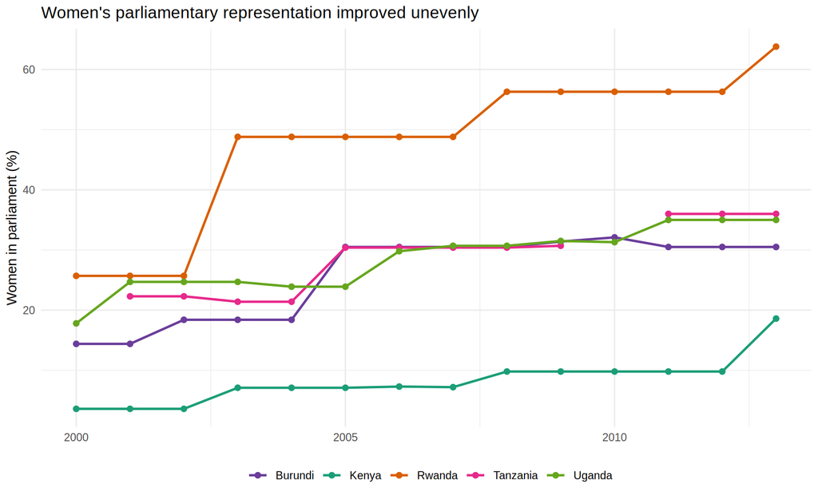

# Regression framework

The empirical specifications are summarized below.

Regression equations used in the analysis

| Model | Equation |
| --- | --- |
| Pooled OLS | g_it = α + β1 FemaleLFP_it + β2 WomenParliament_it + β3 Fertility_it + β4 Capital_it + β5 Inflation_it + β6 Trade_it + ε_it |
| Two-way fixed effects | g_it = α + β1 FemaleLFP_it + β2 WomenParliament_it + β3 Fertility_it + β4 Capital_it + β5 Inflation_it + β6 Trade_it + μ_i + λ_t + ε_it |
| Education-augmented OLS | g_it = α + β1 FemaleLFP_it + β2 WomenParliament_it + β3 SecondaryRatio_it + β4 Fertility_it + β5 Capital_it + β6 Inflation_it + β7 Trade_it + ε_it |

# Regression results

Estimated coefficients

Model

Term

Estimate

SE

Statistic

P_Value

Significance

Pooled OLS

Intercept

2.948

6.320

0.466

0.643

Pooled OLS

Female labor force participation

0.034

0.057

0.589

0.558

Pooled OLS

Women in parliament

0.076

0.038

1.999

0.051

Pooled OLS

Fertility rate

-0.894

0.634

-1.410

0.165

Pooled OLS

Gross capital formation

0.015

0.106

0.137

0.892

Pooled OLS

Inflation

-0.136

0.062

-2.189

0.033

Pooled OLS

Trade openness

0.022

0.063

0.357

0.722

Two-way FE (HC1)

Intercept

27.651

21.931

1.261

0.216

Two-way FE (HC1)

Female labor force participation

0.088

0.279

0.314

0.756

Two-way FE (HC1)

Women in parliament

-0.184

0.108

-1.707

0.096

Two-way FE (HC1)

Fertility rate

-5.153

3.606

-1.429

0.162

Two-way FE (HC1)

Gross capital formation

0.017

0.072

0.232

0.818

Two-way FE (HC1)

Inflation

-0.020

0.066

-0.299

0.767

Two-way FE (HC1)

Trade openness

0.012

0.057

0.207

0.837

Education-augmented OLS

Intercept

-29.732

22.573

-1.317

0.197

Education-augmented OLS

Female labor force participation

0.007

0.174

0.041

0.968

Education-augmented OLS

Women in parliament

0.123

0.083

1.479

0.149

Education-augmented OLS

Girls-to-boys secondary enrollment ratio

19.170

10.064

1.905

0.066

Education-augmented OLS

Fertility rate

1.597

1.345

1.188

0.244

Education-augmented OLS

Gross capital formation

0.002

0.167

0.012

0.990

Education-augmented OLS

Inflation

-0.099

0.119

-0.831

0.412

Education-augmented OLS

Trade openness

0.080

0.108

0.740

0.465

## Model fit summary

Model fit summary

| Model | Sample | Observations | R_Squared | Adj_R_Squared | AIC | BIC |
| --- | --- | --- | --- | --- | --- | --- |
| Pooled OLS | Baseline sample | 58 | 0.353 | 0.276 | 272.7 | 289.2 |
| Two-way FE (HC1) | Baseline sample | 58 | 0.763 | 0.625 | 244.3 | 291.7 |
| Education-augmented OLS | Education sample | 40 | 0.368 | 0.230 | 202.6 | 217.8 |

# Interpretation

The descriptive evidence shows that female labor force participation remained comparatively high across the region, while women’s parliamentary representation improved markedly in several countries. The regression tables should be read as associative rather than strictly causal estimates, but they provide a compact way to compare whether years with stronger gender inclusion indicators tend to coincide with faster GDP per capita growth.

The two-way fixed effects model is the most conservative specification because it removes time-invariant country differences and common year shocks. The education-augmented model uses a smaller sample because secondary enrollment series are incomplete for some country-year combinations.

# Reproducibility